# R Notebook

Loading the necessary library’s

Read the data

```r
computers <- read_csv("data/computers.csv")
head(computers)
```

| X1 | price | speed | hd | ram | screen | cd | multi | premium | ads | trend |
| --- | --- | --- | --- | --- | --- | --- | --- | --- | --- | --- |
| 1 | 1499 | 25 | 80 | 4 | 14 | no | no | yes | 94 | 1 |
| 2 | 1795 | 33 | 85 | 2 | 14 | no | no | yes | 94 | 1 |
| 3 | 1595 | 25 | 170 | 4 | 15 | no | no | yes | 94 | 1 |
| 4 | 1849 | 25 | 170 | 8 | 14 | no | no | no | 94 | 1 |
| 5 | 3295 | 33 | 340 | 16 | 14 | no | no | yes | 94 | 1 |
| 6 | 3695 | 66 | 340 | 16 | 14 | no | no | yes | 94 | 1 |

Lets clean the names

```r
computers <- computers %>%
  clean_names()
```

Select the relevant columns

```r
computers <- computers %>%
  select(c(hard_drive = hd, random_access_memory = ram))

computers
```

| hard_drive | random_access_memory |
| --- | --- |
| 80 | 4 |
| 85 | 2 |
| 170 | 4 |
| 170 | 8 |
| 340 | 16 |
| 340 | 16 |
| 170 | 4 |
| 85 | 2 |
| 210 | 8 |
| 210 | 4 |

[output cut: 990 more lines]

```r
summary(computers)
```

```
   hard_drive     random_access_memory
 Min.   :  80.0   Min.   : 2.000
 1st Qu.: 214.0   1st Qu.: 4.000
 Median : 340.0   Median : 8.000
 Mean   : 416.6   Mean   : 8.287
 3rd Qu.: 528.0   3rd Qu.: 8.000
 Max.   :2100.0   Max.   :32.000
```

Let us now scale the data

```r
computers_scale <- computers %>%
                  mutate_all(scale)

computers_scale
```

| hard_drive | random_access_memory |
| --- | --- |
| -1.30189023 | -0.76129843 |
| -1.28255149 | -1.11646890 |
| -0.95379299 | -0.76129843 |
| -0.95379299 | -0.05095751 |
| -0.29627598 | 1.36972433 |
| -0.29627598 | 1.36972433 |
| -0.95379299 | -0.76129843 |
| -1.28255149 | -1.11646890 |
| -0.79908310 | -0.05095751 |
| -0.79908310 | -0.76129843 |

[output cut: 990 more lines]

lets now plot this data as its scaled and take a look at it

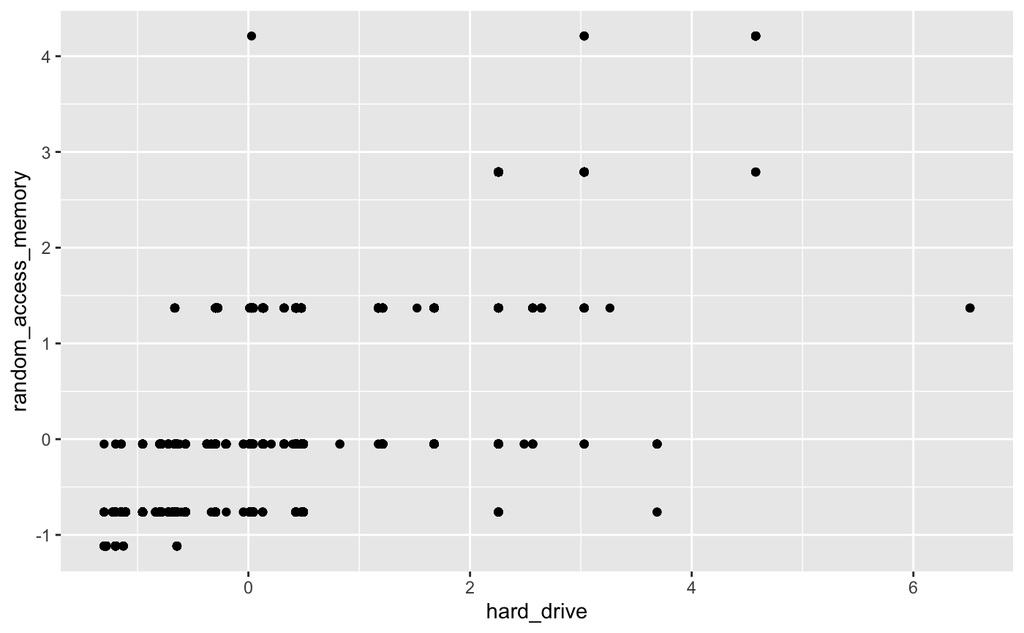

```r
ggplot(computers_scale , aes(hard_drive, random_access_memory))+
  geom_point()
```

On the looks of it, we can see that there are at least 3 to 4 groups,

However lets confirm the same by checking the value of K by using the 3 method’s

Method 1 - Elbow method

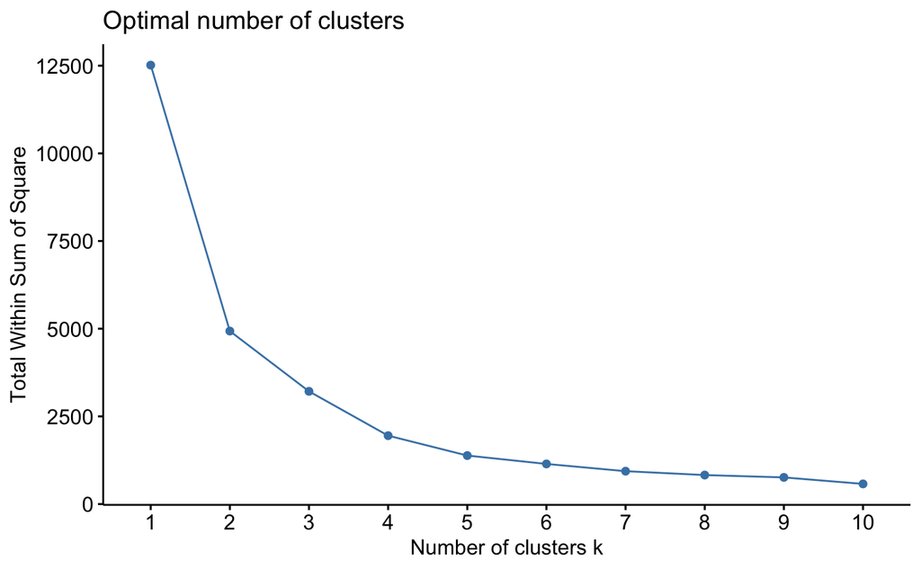

```r
library(factoextra)

fviz_nbclust(computers_scale, kmeans, method = "wss", nstart = 25)
```

Looks like there are 2 strong bends in the elbow, first one is at 2 and the second is at 4,

Lets check the other two methods and see what the outcome of k will be.

Method 2 - Silhouette coefficient

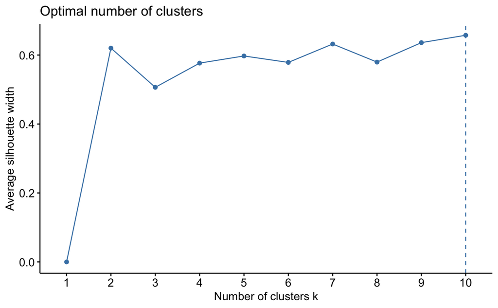

```r
fviz_nbclust(computers_scale, kmeans, method = "silhouette", nstart = 25)
```

As we know the “Silhouette coefficient” takes the highets value of “k”, this data set will not be of a good regerence as k has been more or less constant after the 4th point, more importantly the highest value of “k” is at the 10th point, which we will not condider and will now consider the third methord which is Gap Statistics

Method 3 - Gap statistic

[output not shown]

[output not shown]

[output not shown]

[output not shown]

[output not shown]

[output not shown]

[output not shown]

[output not shown]

[output not shown]

[output not shown]

[output not shown]

[output not shown]

[output not shown]

[output not shown]

[output not shown]

[output not shown]

[output not shown]

[output not shown]

[output not shown]

[output not shown]

[output not shown]

[output not shown]

[output not shown]

[output not shown]

[output not shown]

[output not shown]

[output not shown]

[output not shown]

[output not shown]

[output not shown]

[output not shown]

[output not shown]

[output not shown]

[output not shown]

[output not shown]

[output not shown]

[output not shown]

[output not shown]

[output not shown]

[output not shown]

[output not shown]

[output not shown]

[output not shown]

[output not shown]

[output not shown]

[output not shown]

[output not shown]

[output not shown]

[output not shown]

[output not shown]

[output not shown]

[output not shown]

[output not shown]

[output not shown]

[output not shown]

[output not shown]

[output not shown]

[output not shown]

[output not shown]

[output not shown]

[output not shown]

[output not shown]

[output not shown]

[output not shown]

[output not shown]

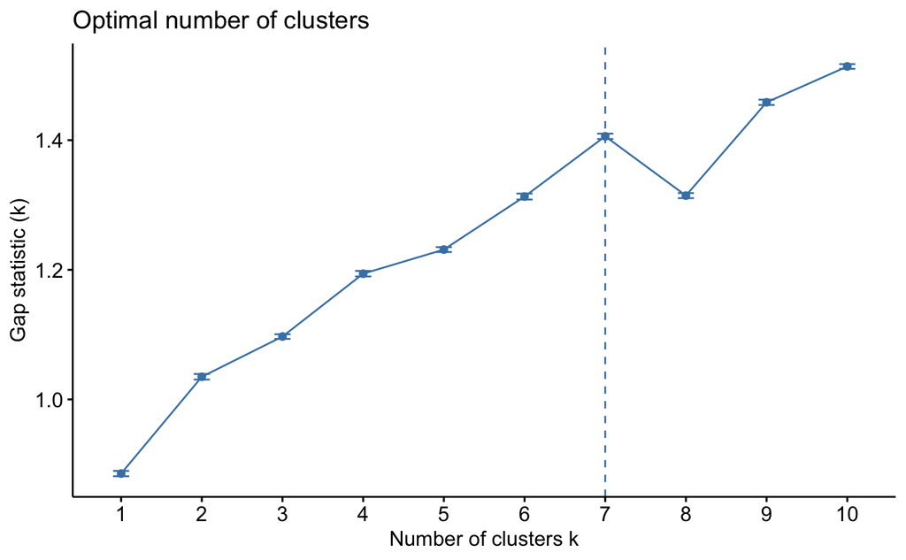

```r
fviz_nbclust(computers_scale, kmeans, method = "gap_stat", nstart = 25, k.max = 10)
```

As all 3 method give quite different results it can be a sign that our data is not well suited for k-means clustering.

However Let us go with the value of K being 7 and create clusters

```r
clustered_computers <- kmeans(computers_scale, centers = 7, nstart = 25)

clustered_computers
```

```
K-means clustering with 7 clusters of sizes 1443, 315, 745, 2007, 316, 612, 821

Cluster means:
   hard_drive random_access_memory
1  0.28448917          -0.05095751
2  2.09939430           0.69997432
3 -0.48509991          -0.05095751
4 -0.91618122          -0.83102298
5  2.53457219           2.84885195
6 -0.08251343          -0.76129843
7  0.46031848           1.36972433

Clustering vector:
   [1] 4 4 4 3 7 7 4 4 3 4 3 3 4 3 3 4 4 4 4 1 4 4 7 4 1 4 4 1 7 3 4 4 3 4 4 4 3 1 3 3 3 1 3 3 7 3 4 4 4 4 4 4 3 4 3 4 4 4 3 4 3
  [62] 4 3 4 4 4 4 4 4 3 1 4 4 3 4 3 3 3 4 3 4 3 3 3 3 3 3 4 4 3 4 4 3 3 7 4 4 4 7 4 4 3 4 6 4 3 3 4 4 4 3 4 1 7 4 4 4 3 4 4 4 4
 [123] 3 3 3 3 4 3 4 4 4 4 4 4 4 3 3 4 3 4 3 1 3 4 1 3 4 4 3 1 4 3 3 3 3 3 4 3 4 4 4 4 4 3 7 4 3 4 4 3 3 3 4 3 1 4 4 3 4 4 4 4 4
 [184] 3 1 3 4 3 7 7 4 4 3 4 4 3 4 4 4 3 1 3 3 4 4 4 3 1 4 1 3 3 3 4 3 4 3 4 7 4 3 3 3 1 3 3 4 7 4 3 3 3 4 3 3 4 4 4 4 1 4 4 3 3
 [245] 3 3 7 3 4 4 3 4 3 4 4 4 3 4 4 7 3 3 3 3 4 4 3 3 7 6 4 1 3 7 3 7 4 3 3 4 3 4 4 4 3 3 4 3 7 4 1 4 3 3 4 7 3 7 4 4 4 4 4 7 3
 [306] 4 3 3 3 1 3 3 7 1 3 4 4 3 3 4 3 7 7 3 4 4 3 4 7 4 4 4 4 4 4 7 4 7 3 3 4 3 3 4 3 3 4 3 3 4 3 3 3 4 4 4 7 3 3 3 4 4 3 3 3 4
 [367] 4 3 4 3 3 4 3 3 4 4 7 7 4 4 3 3 7 3 3 3 4 4 4 4 4 3 4 4 4 7 4 4 4 3 3 4 3 7 7 4 3 3 3 7 4 4 4 3 7 4 3 4 1 4 7 7 4 3 3 4 7
 [428] 3 4 3 7 7 7 4 6 4 3 4 3 7 3 3 4 4 3 7 3 4 4 3 4 3 3 3 3 3 3 4 3 7 3 4 1 7 4 4 3 4 1 1 3 4 3 1 4 4 3 4 3 4 3 4 4 4 3 3 4 6
 [489] 3 3 2 1 4 1 3 3 7 4 4 3 4 4 4 3 3 4 3 7 3 1 1 3 7 4 4 3 4 4 4 4 4 3 4 3 4 7 3 4 4 3 3 4 7 3 4 3 4 4 1 4 7 3 4 3 3 3 4 1 4
 [550] 4 3 4 7 4 7 4 3 7 7 4 7 4 4 3 3 4 4 4 4 3 4 3 4 4 4 3 4 7 3 4 4 3 1 3 1 4 7 4 4 4 3 4 7 4 4 4 1 3 4 4 3 7 4 7 4 4 3 4 3 4
 [611] 7 6 3 3 4 2 4 3 4 4 3 4 1 3 4 1 3 4 4 3 4 4 4 4 4 4 3 4 4 3 4 3 4 7 4 7 7 3 3 4 3 3 3 3 4 3 3 4 3 3 7 4 3 4 4 1 7 4 4 6 3
 [672] 7 1 7 3 3 3 4 1 4 3 4 3 1 4 3 1 1 3 1 4 3 4 7 4 4 3 4 7 4 4 4 3 7 4 4 7 4 4 4 7 3 4 1 4 4 7 7 1 1 2 4 3 4 6 4 3 7 1 4 4 4
 [733] 3 4 4 4 4 3 7 7 7 4 4 3 4 7 3 4 4 3 4 3 4 7 3 3 4 3 4 4 4 4 4 7 4 4 7 4 4 1 3 4 7 7 7 3 4 4 7 1 4 4 7 3 3 3 4 3 4 7 4 7 4
 [794] 3 4 1 7 4 7 3 4 7 4 1 4 3 4 3 3 4 3 4 4 7 4 4 3 4 4 4 3 3 3 3 7 4 4 4 4 7 1 4 4 3 4 4 7 3 4 3 1 3 1 7 3 4 4 4 4 4 4 3 1 4
 [855] 7 3 4 4 4 3 3 4 4 4 1 4 4 3 3 3 4 4 3 4 4 3 3 4 4 3 3 7 4 3 7 4 4 7 4 4 1 7 4 4 3 4 7 7 4 3 2 3 7 4 3 4 4 4 7 4 7 4 4 3 4
 [916] 4 4 4 4 4 3 4 3 3 4 4 3 3 3 4 4 7 4 4 4 3 3 3 4 4 3 7 4 4 6 3 4 3 4 4 7 1 4 4 7 3 4 3 3 7 3 4 3 4 1 7 4 4 4 1 1 1 1 4 6 1
 [977] 4 4 4 4 4 2 7 3 1 3 4 4 4 4 4 4 4 2 7 1 1 4 3 4
 [ reached getOption("max.print") -- omitted 5259 entries ]

Within cluster sum of squares by cluster:
[1] 125.46233 246.58534  36.02784 121.99691 189.37178  49.46172 168.14783
 (between_SS / total_SS =  92.5 %)

Available components:

[1] "cluster"      "centers"      "totss"        "withinss"     "tot.withinss" "betweenss"    "size"         "iter"
[9] "ifault"
```

Let us visualise this

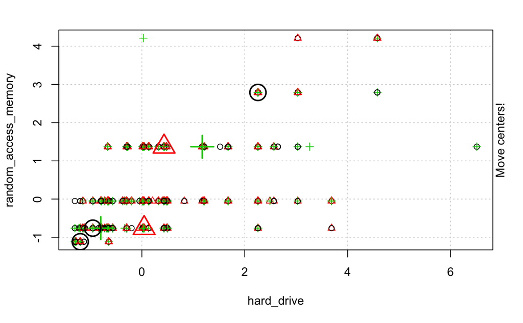

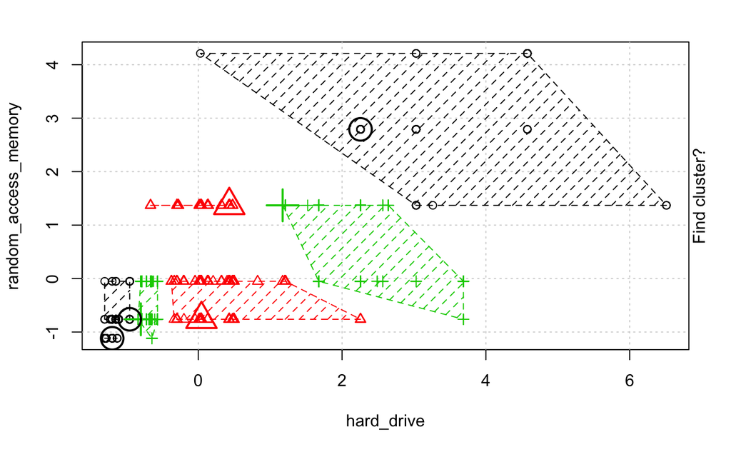

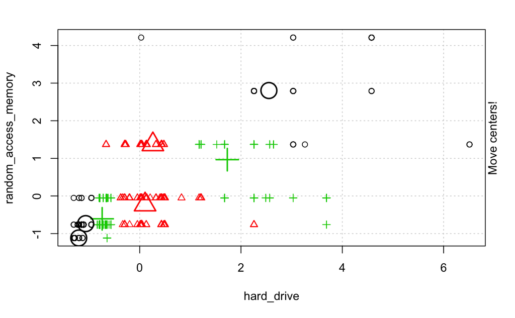

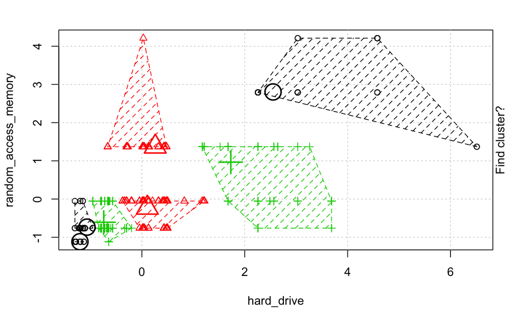

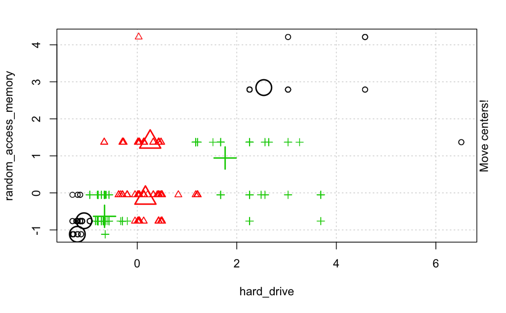

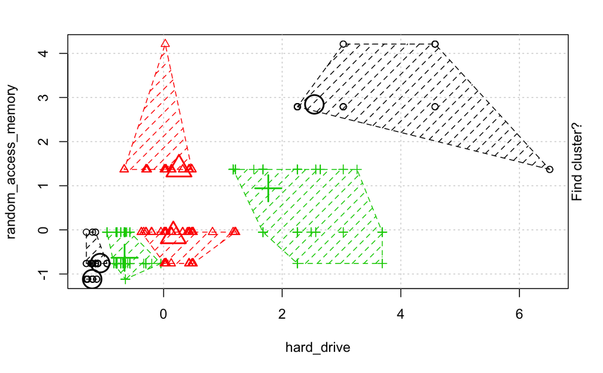

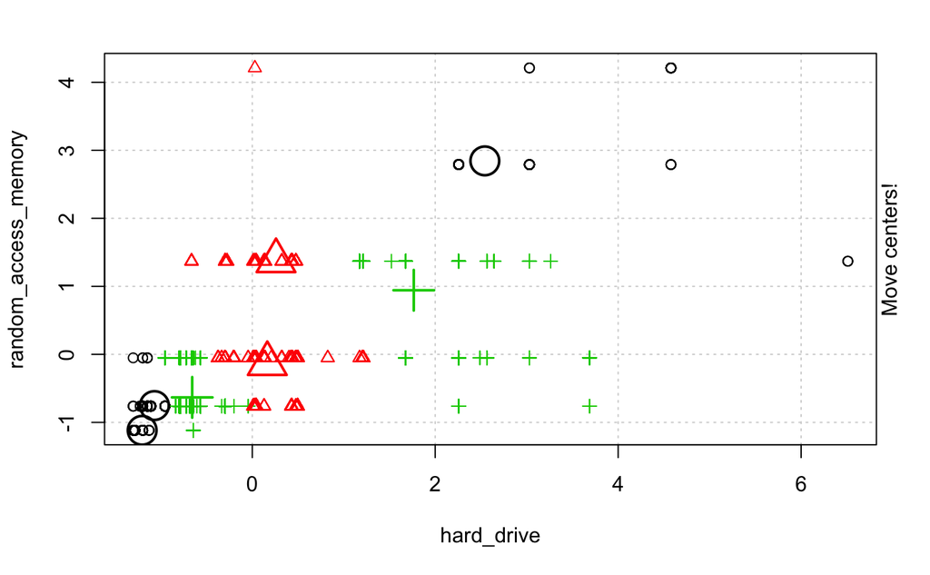

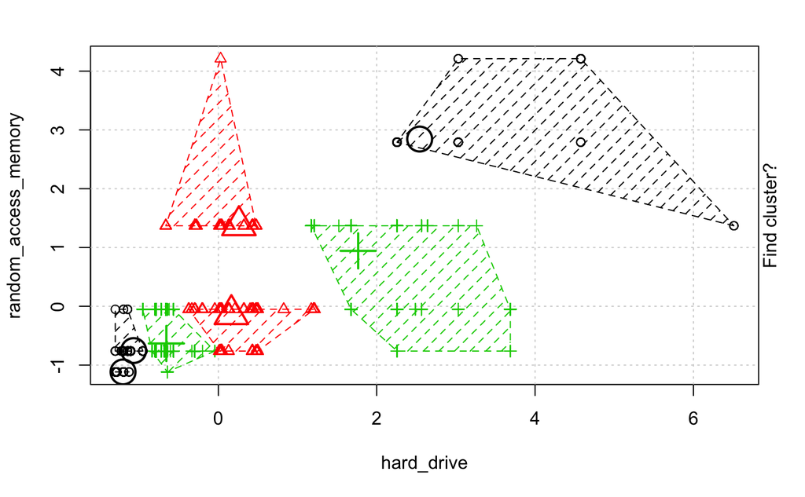

```r
library(animation)

computers_scale %>%
  kmeans.ani(centers = 7)
```

The functions tidy(), augment() and glance() functions pull out the information we will be interested from kmeans in but in a ‘tidy’ format:

```r
library(broom)

tidy(clustered_computers,
     col.names = colnames(computers_scale))
```

| hard_drive | random_access_memory | size | withinss | cluster |
| --- | --- | --- | --- | --- |
| 0.28448917 | -0.05095751 | 1443 | 125.46233 | 1 |
| 2.09939430 | 0.69997432 | 315 | 246.58534 | 2 |
| -0.48509991 | -0.05095751 | 745 | 36.02784 | 3 |
| -0.91618122 | -0.83102298 | 2007 | 121.99691 | 4 |
| 2.53457219 | 2.84885195 | 316 | 189.37178 | 5 |
| -0.08251343 | -0.76129843 | 612 | 49.46172 | 6 |
| 0.46031848 | 1.36972433 | 821 | 168.14783 | 7 |

```r
glance(clustered_computers)
```

| totss | tot.withinss | betweenss | iter |
| --- | --- | --- | --- |
| 12516 | 937.0537 | 11578.95 | 2 |

And augment() gives us which cluster each observation in original data set has been assigned to (by feeding it both the clustered data and the original data):

```r
augment(clustered_computers, computers)
```

| hard_drive | random_access_memory | .cluster |
| --- | --- | --- |
| 80 | 4 | 4 |
| 85 | 2 | 4 |
| 170 | 4 | 4 |
| 170 | 8 | 3 |
| 340 | 16 | 7 |
| 340 | 16 | 7 |
| 170 | 4 | 4 |
| 85 | 2 | 4 |
| 210 | 8 | 3 |
| 210 | 4 | 4 |

[output cut: 990 more lines]

```r
library(broom)

# Set min & max number of clusters want to look at
max_k <- 20

k_clusters <- tibble(k = 1:max_k) %>%
  mutate(
    kclust = map(k, ~ kmeans(computers_scale, .x, nstart = 25)),
    tidied = map(kclust, tidy),
    glanced = map(kclust, glance),
    augmented = map(kclust, augment, computers)
  )

k_clusters
```

| k | kclust | tidied | glanced | augmented |
| --- | --- | --- | --- | --- |
| 1 |  |  |  |  |
| 2 |  |  |  |  |
| 3 |  |  |  |  |
| 4 |  |  |  |  |
| 5 |  |  |  |  |
| 6 |  |  |  |  |
| 7 |  |  |  |  |
| 8 |  |  |  |  |
| 9 |  |  |  |  |
| 10 |  |  |  |  |

[output cut: 10 more lines]

```r
clusterings <- k_clusters %>%
  unnest(glanced)
```

Another way to visualise the data is via ggplot. You can visualise for all the values of k

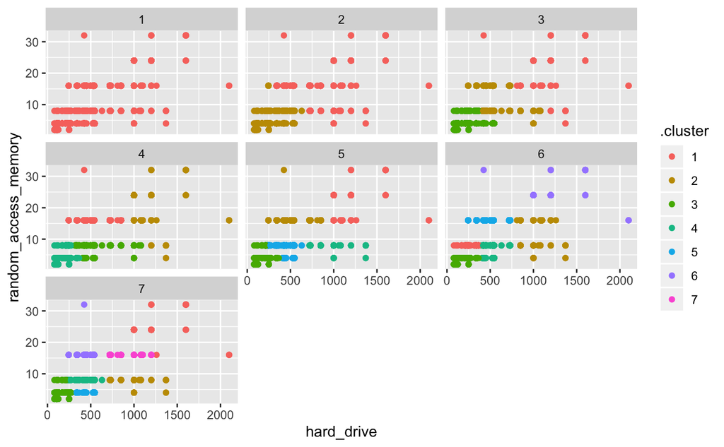

```r
clusterings %>%
  unnest(cols = c(augmented)) %>%
  filter(k <= 7) %>%
 ggplot(aes(x = hard_drive, y = random_access_memory)) +
  geom_point(aes(color = .cluster)) +
  facet_wrap(~ k)
```

```r
 clusterings %>%
  unnest(augmented) %>%
  filter(k == 2) %>%
  group_by(.cluster) %>%
  summarise(mean(hard_drive), mean(random_access_memory))
```

| .cluster | mean(hard_drive) | mean(random_access_memory) |
| --- | --- | --- |
| 1 | 746.8442 | 16.567657 |
| 2 | 311.1385 | 5.642496 |

Although We see that the averages for hard_drive and RAM figures are quite different for each of the clusters which is a sign that the clusters are quite different. However the graphs and the fact that k value has constantly been varying over the three models, we would recomend looking at other methods of spliting the data rather than relying on K Means Clustering for this set of data.